[GitHub](https://github.com/agate-model/Agate.jl)[](https://github.com/agate-model/Agate.jl/blob/main/examples/size_structure.jl)

# Size structure example

Info

This example uses [Oceananigans.jl](https://clima.github.io/OceananigansDocumentation/stable/) and [OceanBioME.jl](https://oceanbiome.github.io/OceanBioME.jl/stable/). We recommend familiarizing yourself with their user interface if you intend to make changes to the physical model setup.

This example changes the number of plankton and the size structure of the Agate.jl-NiPiZD model.

## Loading dependencies

The example uses Agate.jl, Oceananigans.jl, and OceanBioME.jl for the ecosystem simulation. CairoMakie.jl is used for plotting.

```julia
using Agate
using Agate.Introspection: tracer_names, plankton_tracers, plankton_diameters
using Agate.Library.Light
using OceanBioME
using OceanBioME: Biogeochemistry
using Oceananigans
using Oceananigans.Units
using CairoMakie
```

## Ecosystem model

The plankton size structure is configured separately for phytoplankton and zooplankton. Here, phytoplankton are split into three classes spanning 1 to 10 μm equivalent spherical diameter (ESD), using logarithmic spacing.

```julia
phyto_size_structure = (n=3, min_esd=1, max_esd=10, splitting=:log_splitting)
```

Alternatively, an explicit array can be used. This zooplankton size structure also defines three classes, specifying the ESD of each class directly.

```julia
zoo_size_structure = [10.0, 32.0, 100.0]
```

```
3-element Vector{Float64}:
  10.0
  32.0
 100.0
```

The model is constructed following the default model setup but with the custom size structures. This creates three phytoplankton tracers and three zooplankton tracers.

```julia
bgc = Agate.Models.NiPiZD.construct(; phyto_size_structure, zoo_size_structure)
```

We can inspect the tracer names required by the model.

```julia
println(tracer_names(bgc))
```

```
[:N, :D, :Z1, :Z2, :Z3, :P1, :P2, :P3]
```

As well as the plankton sizes:

```julia
for (name, diameter) in zip(plankton_tracers(bgc), plankton_diameters(bgc))
    println(name, ": ", diameter, " μm")
end
```

```
Z1: 10.0 μm
Z2: 32.0 μm
Z3: 100.0 μm
P1: 1.0 μm
P2: 3.1622776601683795 μm
P3: 10.000000000000002 μm
```

## Physical model

Next, we define the light model and combine it with the Agate.jl ecosystem model using OceanBioME.jl. The `BoxModelGrid` represents a well-mixed zero-dimensional water column.

```julia
light_attenuation = FunctionFieldPAR(; grid=BoxModelGrid())

bgc_model = Biogeochemistry(bgc; light_attenuation)

full_model = BoxModel(; biogeochemistry=bgc_model)
```

## Initial conditions

```julia
set!(full_model; N=8.0, P1=0.01, P2=0.05, P3=0.1, Z1=0.01, Z2=0.01, Z3=0.01, D=0.01)
```

## Simulation

```julia
filename = "size_structure.jld2"

simulation = Simulation(full_model; Δt=240minutes, stop_time=1095days)

simulation.output_writers[:fields] = JLD2Writer(
    full_model,
    full_model.fields;
    filename,
    schedule=TimeInterval(1day),
    overwrite_existing=true,
)

run!(simulation)
```

```
[ Info: Initializing simulation...
[ Info:     ... simulation initialization complete (2.070 seconds)
[ Info: Executing initial time step...
[ Info:     ... initial time step complete (853.087 ms).
[ Info: Simulation is stopping after running for 6.936 seconds.
[ Info: Simulation time 1095 days equals or exceeds stop time 1095 days.
```

## Plotting

Load the simulated tracer time series from disk.

```julia
tracer_syms = tracer_names(bgc)

timeseries = (;
    (s => FieldTimeSeries(filename, string(s))[1, 1, 1, :] for s in tracer_syms)...
)
```

Plot each tracer concentration through time.

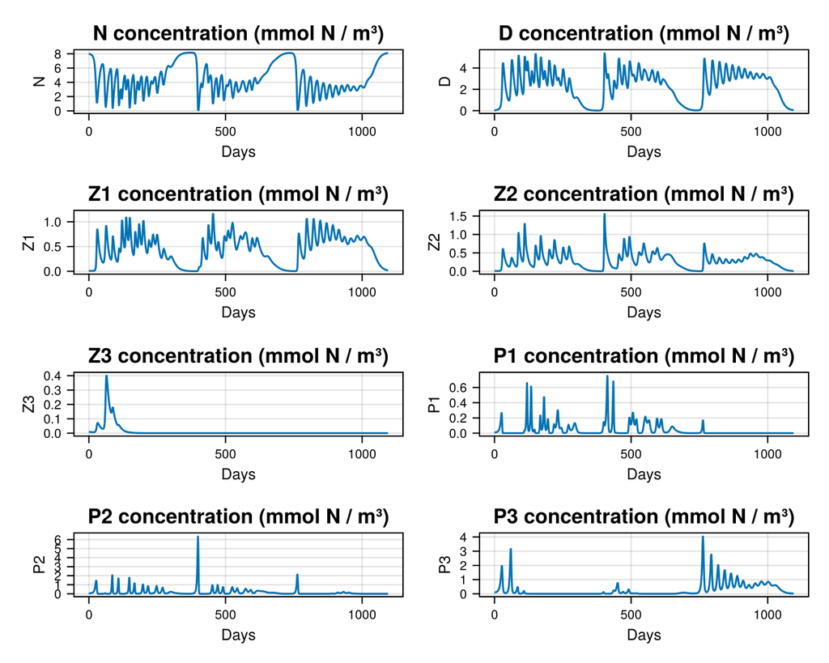

```julia
times = FieldTimeSeries(filename, string(first(tracer_syms))).times

fig = Figure(; size=(650, 520), fontsize=12)

for (idx, sym) in enumerate(tracer_syms)
    ax = Axis(
        fig[floor(Int, (idx - 1) / 2), Int((idx - 1) % 2)];
        ylabel=string(sym),
        xlabel="Days",
        title="$(sym) concentration (mmol N / m³)",
        titlesize=16,
        xlabelsize=12,
        ylabelsize=12,
        xticklabelsize=10,
        yticklabelsize=10,
    )
    lines!(ax, times / day, getproperty(timeseries, sym); linewidth=1.5)
end

fig
```

*This page was generated using Literate.jl.*